# Lab 6 Estimating the Reduction in At-Risk Infant Mortality Attributable to NICU Care Using a Regression Discontinuity Design

Class 8 Regression Discontinuity

Tony Lim

# Overview

The goal of this analysis is to estimate the reduction in mortality attributable to care in the neonatal intensive care unit (NICU), using a regression discontinuity design. We will aim to replicate the main results from the paper [“Estimating marginal returns to medical care: evidence from at-risk newborns” by Almond, Doyle, Kowalski and Williams (Quarterly Journal of Economics, 2010)](https://academic.oup.com/qje/article/125/2/591/1882183).

```r
library(dplyr)
library(ggplot2)
library(jtools)
library(tidyverse)
```

Load the data file `NICU.csv`. Next, we will adjust an R setting so the results display in decimal format (e.g., 0.00123) instead of scientific notation (1.23e-3).

```r
NICU <- read_csv("NICU.csv")
options("scipen" = 100, "digits" = 3)
```

# Data Summary

The full dataset includes U.S. births between 1983 and 2002 (approximately 66 million births). For this analysis, we use a sub-sample of at-risk newborns: those with birth weights within 85g (3 oz) of the 1500g (3 lbs, 5 oz) cut-off for NICU care. The dataset contains the following variables for each newborn baby:

- **GestAge:** gestational age of newborn in weeks
- **Weight:** birth weight in grams
- **Death:** death within one year of birth (1 = death, 0 = no death)

## Question 1

How many births are included in the dataset? What is the average gestational age and birth weight? What is the mortality rate within 1 year of birth?

```r
NICU %>%
  print(width = Inf)
```

```
## # A tibble: 194,803 x 3
##    GestAge Weight Death
##      <dbl>  <dbl> <dbl>
##  1      36   1503     0
##  2      27   1503     0
##  3      30   1503     0
##  4      30   1503     0
##  5      36   1503     0
##  6      29   1503     0
##  7      39   1503     0
##  8      32   1503     0
##  9      29   1503     1
## 10      33   1513     0
## # ... with 194,793 more rows
```

There are 194,803 births included in the dataset.

```r
sapply(NICU, mean, na.rm = T)
```

```
##   GestAge    Weight     Death
##   32.1925 1494.7744    0.0567
```

The average gestational age is 32.2 weeks, and the average birth weight is 1494.8 grams. The mortality rate within 1 year of birth is 0.0567 or 5.67 deaths per 100 births.

## Question 2

Create a dummy variable called `VLBW` (very low birth weight) for newborns with weight below 1500g. Create an interaction variable called `Below`, which equals `VLBW` x (`Weight` - 1500). Create another interaction variable called `Above`, which equals (1 - `VLBW`) x (`Weight` - 1500).

```r
NICU <- NICU %>%
  mutate(VLBW = ifelse(Weight < 1500, 1, 0),
         Below = VLBW * (Weight - 1500),
         Above = (1 - VLBW) * (Weight - 1500))

NICU %>%
  print(width = Inf)
```

```
## # A tibble: 194,803 x 6
##    GestAge Weight Death  VLBW Below Above
##      <dbl>  <dbl> <dbl> <dbl> <dbl> <dbl>
##  1      36   1503     0     0     0     3
##  2      27   1503     0     0     0     3
##  3      30   1503     0     0     0     3
##  4      30   1503     0     0     0     3
##  5      36   1503     0     0     0     3
##  6      29   1503     0     0     0     3
##  7      39   1503     0     0     0     3
##  8      32   1503     0     0     0     3
##  9      29   1503     1     0     0     3
## 10      33   1513     0     0     0    13
## # ... with 194,793 more rows
```

# Data Visualization

Here, we will review how to create histograms and scatterplots. Note, you can adjust the bar fill and outline color as you like. Here’s a link to many built-in colors in R: http://sape.inf.usi.ch/quick-reference/ggplot2/colour

## Question 3

Plot a histogram of birth weight in grams, setting the binwidth to 10 grams. What do you think is going on here?

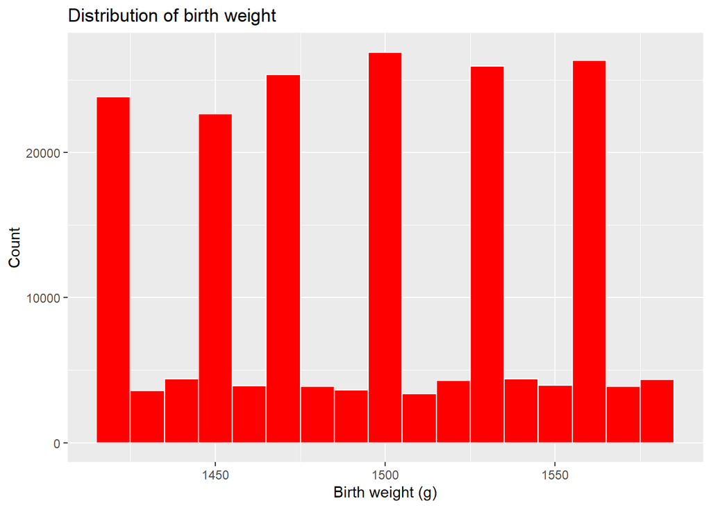

```r
NICU %>%
  ggplot(mapping = aes(x = Weight)) +
  geom_histogram(fill = "#FF0000",
                 color = "white",
                 binwidth = 10) +
  labs(title = "Distribution of birth weight",
       x = "Birth weight (g)",
       y = "Count")
```

There are peaks at birth weights that are multiples of around 28 grams. This may have occurred because nurses or health professionals rounded to a nice, even birth weight in ounces, and an ounce is about 28 grams.

## Question 4

Convert birth weight to ounces, by dividing the weight in grams by 28.34952. Plot another histogram of birth weight in ounces, setting the binwidth to 0.1 ounces. Now, what might explain this pattern?

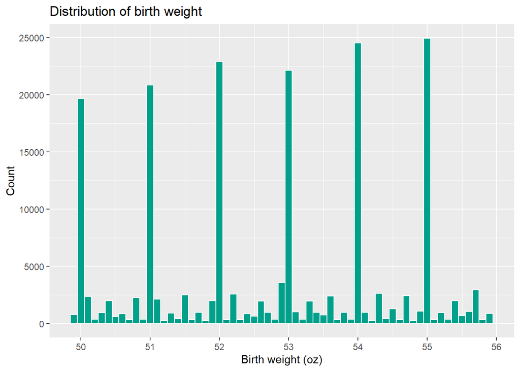

```r
NICU %>%
  ggplot(mapping = aes(x = Weight / 28.34952)) +
  geom_histogram(fill = "#00A08A",
                 color = "white",
                 binwidth = 0.1) +
  labs(title = "Distribution of birth weight",
       x = "Birth weight (oz)",
       y = "Count") +
  scale_x_continuous(breaks = seq(50, 56, 1))
```

There are peaks at birth weights that are integers of ounces. This may have occurred because nurses or health professionals rounded to a nice, even integer birth weight in ounces.

# Smooth Covariates

For an RD analysis to be sound, we should verify that other covariates are not “jumping” at the 1500g cut-off. For example, if gestational age (a measure of a newborn’s health) also jumps at 1500g, we might worry that birth weights are being manipulated so as to allow certain babies (e.g., premature) access to the NICU.

## Question 5

Create a scatterplot of each newborn’s gestational age (y-axis) versus birth weight (x-axis). You can play around with different colors too.

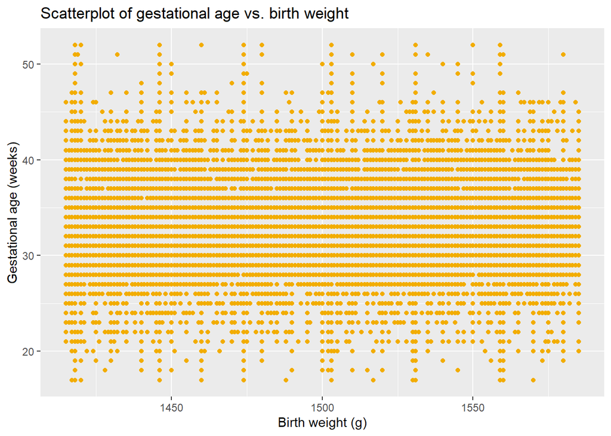

```r
NICU %>%
  ggplot(mapping = aes(x = Weight, y = GestAge)) +
  geom_point(color = "#F2AD00") +
  labs(title = "Scatterplot of gestational age vs. birth weight",
       x = "Birth weight (g)",
       y = "Gestational age (weeks)")
```

The previous graph is hard to interpret because we have so many data points. Instead, let’s group newborns by `Weight` (in grams) and calculate the *average* gestational age. We will use the “pipe” operator %>% which passes the dataframe `NICU` to the next line. This will create a new smaller dataframe called `AGE`. Next, create a new scatterplot of the *average* gestational age (y-axis) versus birth weight (x-axis).

Does this appear smooth at the 1500g cut-off? Are gestational age and birth weight positively or negatively correlated? Does that make intuitive sense?

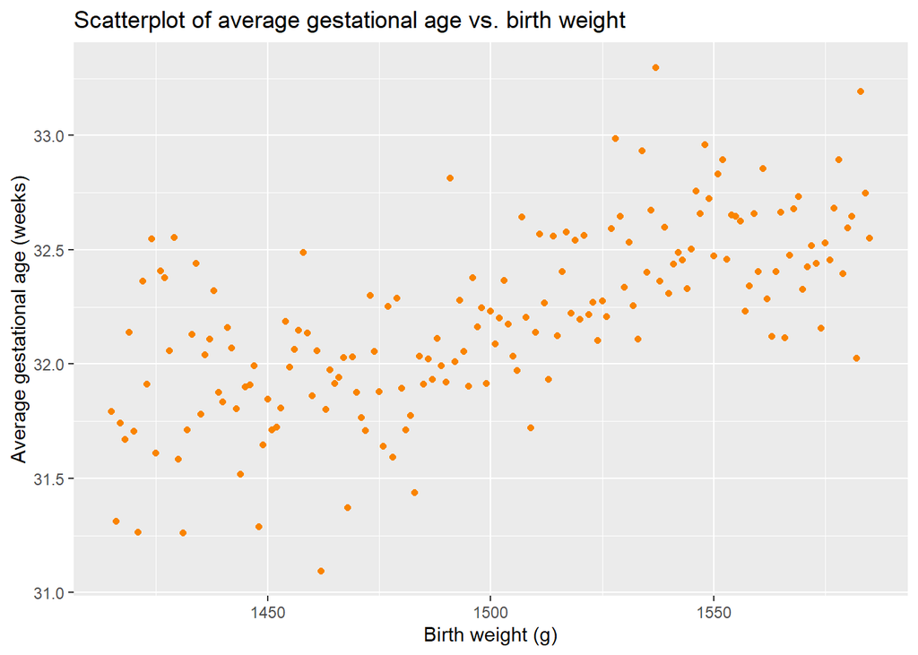

```r
AGE <- NICU %>%
 group_by(Weight) %>%
 summarise(MeanGestAge = mean(GestAge))

AGE %>%
  ggplot(mapping = aes(x = Weight, y = MeanGestAge)) +
  geom_point(color = "#F98400") +
  labs(title = "Scatterplot of average gestational age vs. birth weight",
       x = "Birth weight (g)",
       y = "Average gestational age (weeks)")
```

The graph appears smooth at the 1500g cut-off. Gestational age and birth weight are positively correlated, which make sense since more time spent in the womb means more fetal growth, resulting in a higher birth weight.

# Regression Discontinuity

## Question 6

Run a linear regression with Death as the dependent variable, and your 3 new variables as independent variables. What is the graphical interpretation of each coefficient?

```r
reg1 <- glm(Death ~ VLBW + Below + Above, data = NICU)

summary(reg1)
```

```
##
## Call:
## glm(formula = Death ~ VLBW + Below + Above, data = NICU)
##
## Deviance Residuals:
##     Min       1Q   Median       3Q      Max
## -0.0646  -0.0607  -0.0560  -0.0524   0.9559
##
## Coefficients:
##               Estimate Std. Error t value             Pr(>|t|)
## (Intercept)  0.0613008  0.0012467   49.17 < 0.0000000000000002 ***
## VLBW        -0.0090965  0.0021758   -4.18      0.0000290642732 ***
## Below       -0.0001459  0.0000322   -4.53      0.0000058731301 ***
## Above       -0.0002020  0.0000293   -6.89      0.0000000000058 ***
## ---
## Signif. codes:  0 '***' 0.001 '**' 0.01 '*' 0.05 '.' 0.1 ' ' 1
##
## (Dispersion parameter for gaussian family taken to be 0.0535)
##
##     Null deviance: 10428  on 194802  degrees of freedom
## Residual deviance: 10423  on 194799  degrees of freedom
## AIC: -17547
##
## Number of Fisher Scoring iterations: 2
```

The coefficient estimate for VLBW is -0.009, meaning that babies who have very low birth weights (< 1500 g) have almost a 1% decrease in mortality rate compared to babies weighing >= 1500g since VLBW babies are transferred to the NICU.

Let’s plot the mortality rate by weight. First, we will create 1-ounce bins and then plot the mortality rate by bin

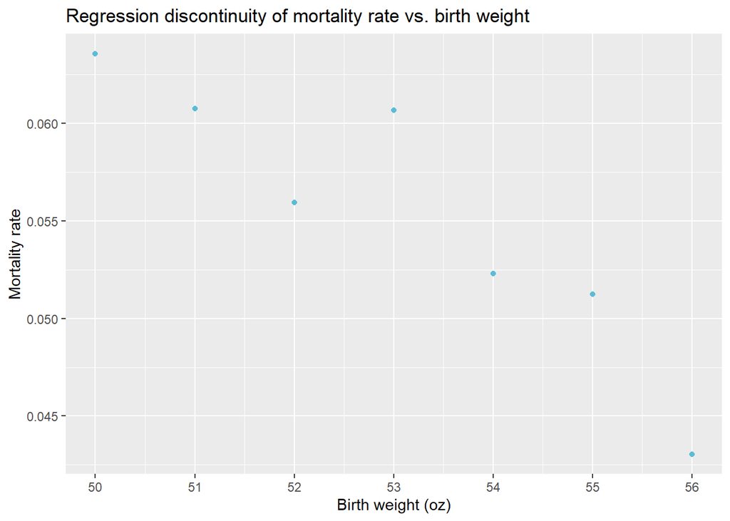

```r
NICU$WeightBin <- round(NICU$Weight / 28.34952)

MORTALITY <- NICU %>%
 group_by(WeightBin) %>%
 summarise(MortalityRate = mean(Death))

MORTALITY %>%
  ggplot(mapping = aes(x = WeightBin, y = MortalityRate)) +
  geom_point(color = "#5BBCD6") +
  labs(title = "Regression discontinuity of mortality rate vs. birth weight",
       x = "Birth weight (oz)",
       y = "Mortality rate") +
  scale_x_continuous(breaks = seq(50, 56, 1))
```

Let’s convert back to grams and add a vertical line at 1500g. This is similar to Figure 2a in the paper.

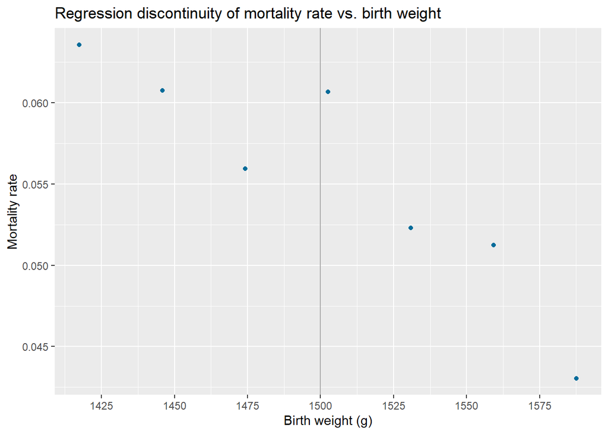

```r
MORTALITY %>%
  ggplot(mapping = aes(x = WeightBin * 28.34952, y = MortalityRate)) +
  geom_point(color = "#046C9A") +
  labs(title = "Regression discontinuity of mortality rate vs. birth weight",
       x = "Birth weight (g)",
       y = "Mortality rate") +
  scale_x_continuous(breaks = seq(1400, 1600, 25)) +
  geom_vline(xintercept = 1500, color = "darkgray")
```

## Question 7

```r
NEWBORNS <- data.frame(
 Weight = c(1499, 1501),
 VLBW = c(1, 0),
 Below = c(-1, 0),
 Above = c(0, 1))

predict(reg1, newdata = NEWBORNS, interval = "confidence")
```

```
##      1      2
## 0.0524 0.0611
```